# Overview of Other Stan-related R Packages

January 15, 2020

## Outline

- There are many R packages that come with Stan programs or do things with Stan output
- Focus here is on those maintained by Stan developers and / or people at Columbia

## The rstanarm Package

The [rstanarm](http://mc-stan.org/rstanarm/) package comes with several Stan programs for regression but uses the same syntax and likelihood as core R functions, such as `lm`, `glm`, `lme4::glmer`, `mgcv::gam`, etc.

```r
(post <- stan_lm(kid_score ~ mom_hs + mom_age + mom_iq, data = kidiq, prior = R2(.3, "mean")))
```

```
...
##             Median MAD_SD
## (Intercept) 22.3    8.8
## mom_hs       5.5    2.2
## mom_age      0.2    0.3
## mom_iq       0.6    0.1
##
## Auxiliary parameter(s):
##               Median MAD_SD
## R2             0.2    0.0
## log-fit_ratio  0.0    0.0
## sigma         18.1    0.6
##
## Sample avg. posterior predictive distribution of y:
##          Median MAD_SD
## mean_PPD 86.8    1.2
##
## ------
## * For help interpreting the printed output see ?print.stanreg
## * For info on the priors used see ?prior_summary.stanreg
...
```

## The shinystan Package

The [shinystan](http://mc-stan.org/shinystan/) package allows you to visualize the posterior distribution, which is particularly useful for diagnosing problems with models

```r
launch_shinystan(post) # opens app in default web browser
```

## The bayesplot Package

The [bayesplot](http://mc-stan.org/bayesplot/) package can be used with rstanarm, rstan, etc. to visualize implications of posterior distributions, such as leave-one-out posterior predictions

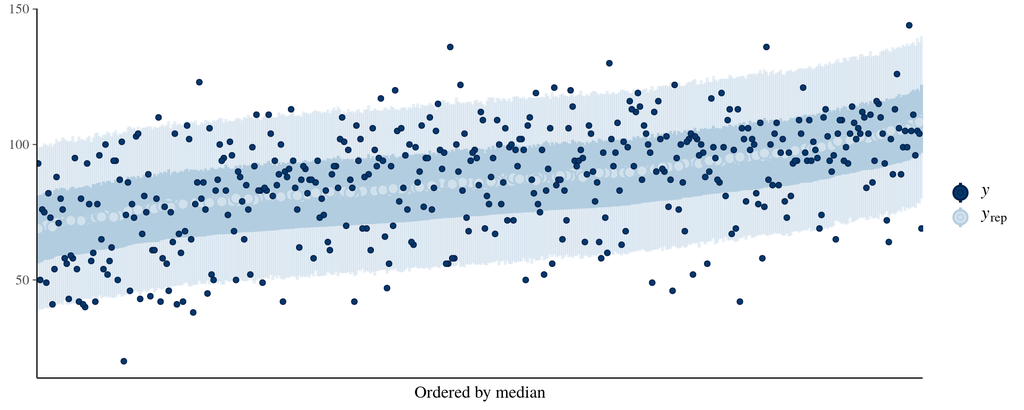

```r
pp_check(post, plotfun = "loo_intervals", order = "median") # -> bayesplot::ppc_loo_intervals
```

## The loo Package

The [loo](http://mc-stan.org/loo/) package calculates an approximation to the Expected Log Predictive Density (ELPD) of \(N\) future observations, which is used for model comparison

```r
loo(post)
```

```
##
## Computed from 4000 by 434 log-likelihood matrix
##
##          Estimate   SE
## elpd_loo  -1876.8 14.3
## p_loo         5.0  0.4
## looic      3753.6 28.6
## ------
## Monte Carlo SE of elpd_loo is 0.0.
##
## All Pareto k estimates are good (k < 0.5).
## See help('pareto-k-diagnostic') for details.
```

## Stacking Weights in the loo Package

The [loo](http://mc-stan.org/loo/) package can also be used to choose the optimal weights over competing models to maximize the ELPD, such as this one that excludes `mom_hs`

```r
post_no_hs <- update(post, formula. = . ~ . -mom_hs)
```

```r
loo_model_weights(stanreg_list(post, post_no_hs))
```

```
## Method: stacking
## ------
##            weight
## post       0.829
## post_no_hs 0.171
```

## The projpred Package

The [projpred](http://mc-stan.org/projpred/) package chooses a submodel of an original model that has almost the same ELPD but still preserves posterior uncertainty correctly

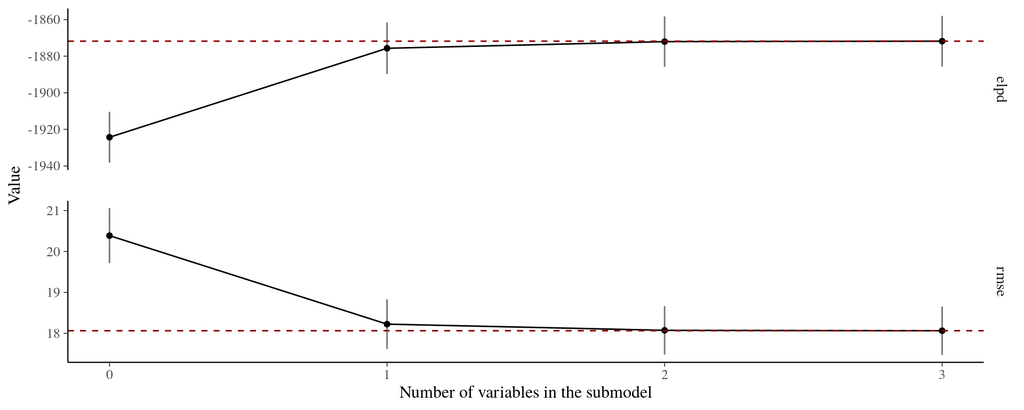

```r
varsel_plot(varsel(post, method = "forward"), stats=c("elpd", "rmse"))
```

## The brms Package

The [brms](https://github.com/paul-buerkner/brms/) package generates Stan programs from R syntax at runtime, which allows it to to fit a more extensive set of regression models flexibly. The `make_stancode` and `make_standata` functions are useful.

```r
(post <- brm(time | cens(censored) ~ age * sex + disease + (1 | patient), data = kidney, family = weibull))
```

```
...
## Group-Level Effects:
## ~patient (Number of levels: 38)
##               Estimate Est.Error l-95% CI u-95% CI Rhat Bulk_ESS Tail_ESS
## sd(Intercept)     0.53      0.25     0.05     1.01 1.01      719      831
##
## Population-Level Effects:
##               Estimate Est.Error l-95% CI u-95% CI Rhat Bulk_ESS Tail_ESS
## Intercept         2.79      0.93     1.03     4.68 1.00     1861     2185
## age               0.02      0.02    -0.03     0.07 1.00     1557     1838
## sexfemale         2.93      1.10     0.73     5.10 1.00     1834     1968
## diseaseGN        -0.28      0.50    -1.31     0.72 1.00     2033     2235
## diseaseAN        -0.57      0.48    -1.53     0.37 1.00     2431     2499
## diseasePKD        0.78      0.74    -0.72     2.21 1.00     2073     2323
## age:sexfemale    -0.03      0.03    -0.08     0.02 1.00     1724     1896
##
## Family Specific Parameters:
##       Estimate Est.Error l-95% CI u-95% CI Rhat Bulk_ESS Tail_ESS
## shape     1.12      0.16     0.85     1.47 1.00     1307     2723
##
## Samples were drawn using sampling(NUTS). For each parameter, Eff.Sample
## is a crude measure of effective sample size, and Rhat is the potential
## scale reduction factor on split chains (at convergence, Rhat = 1).
...
```

## Visualizing Partial Conditional Mean Functions

The [brms](https://github.com/paul-buerkner/brms/) package has an extensive set of plots that allow you to visualize the implications of the models that it estimates

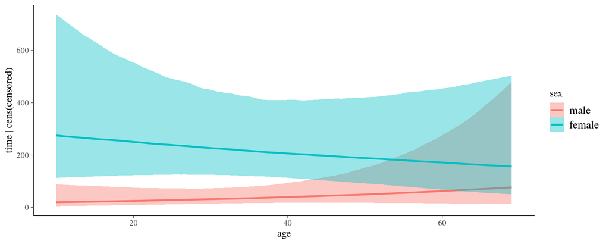

```r
plot(marginal_effects(post, effects = "age:sex"))
```

## Creating your own R Packages that Use Stan

The [rstantools](https://mc-stan.org/rstantools/articles/index.html) package has generic functions and a step-by-step guide for you to create an R package that wraps a Stan program you write

```r
rstan_create_package(path = 'new_package', stan_files = "my_model.stan")
```

At this point, the package directory is setup and can be compiled, but you need to write an R function that inputs syntax and data to be parsed and passed to the `data` block of my_model.stan .

## The bmlm Package

The [bmlm](https://mvuorre.github.io/bmlm/) package was built via `rstantools::rstan_create_package` and comes with Stan programs to estimate mediation models

```r
BLch9 <- isolate(BLch9, by = "id", value = c("fwkstrs", "fwkdis", "freldis"))
post <- mlm(d =  BLch9, id = "id", x = "fwkstrs_cw", m = "fwkdis_cw", y = "freldis_cw")
```

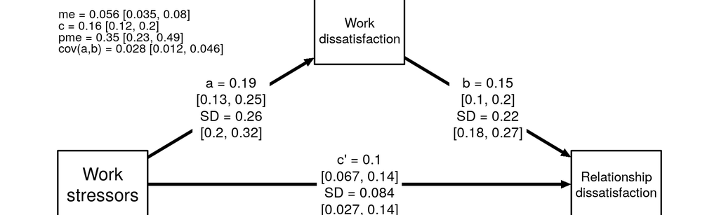

```r
mlm_path_plot(post, level = .9, text = TRUE, digits = 2, xlab = "Work\nstressors",
              mlab = "Work\ndissatisfaction", ylab = "Relationship\ndissatisfaction")
```

## The gbiqq Package

The [gbiqq](https://macartan.github.io/causalmodels/) package comes with a general Stan program that estimates the causal implications of any Directed Acyclic Graph (DAG) with binary nodes only (and it handles missing values)

```r
model <- make_model("X->Y")
data  <- data.frame(X = c(0, 1, 1, NA), Y = c(0, 1, 0, 1))
post  <- update_model(model, data)
```

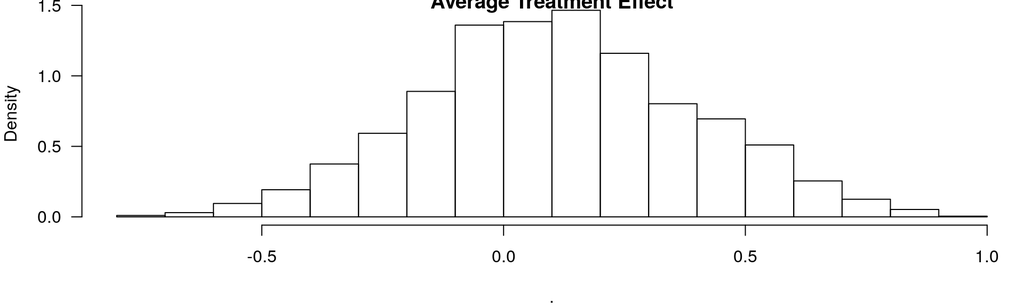

```r
post %>% query_distribution(query = "(Y[X=1] - Y[X=0])", using = "posteriors") %>%
  hist(main = "Average Treatment Effect", prob = TRUE, cex = 0.8)
```

## The torsten Library

The [torsten](https://github.com/metrumresearchgroup/Torsten) library is a fork of Stan that adds functionality for analyzing of pharmacometric data using similar models and data formats as the NONMEM PREDPP software, a registered trademark of ICON Development Solutions.

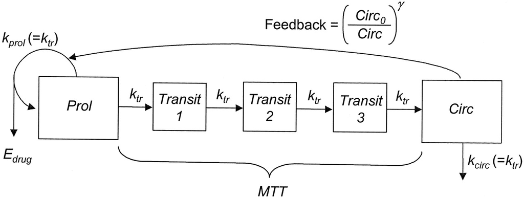

This model is specified as a system of five ODEs that depend on unknown parameters, which is solved with a combination of analytical and numerical integration methods.

## Conclusion

- Any model whose posterior PDF is differentiable can be expressed in the Stan language, perhaps with some C++ extensions
- The MCMC algorithm in Stan gives you the best chance of obtaining a reasonable effective sample size from the entire typical set in a finite time
- Researchers have used Stan to successfully draw from a posterior distribution with over one million dimensions
- With posterior draws, you can make decisions to maximize expected utility
- A lot of research utilizing Stan is at Columbia that you can leverage or add to